Introduction

# Introduction

**Context**

The data in this study reports video games sales in EU, NA, Japan, and other places. Inlcuded also are the names of the games, the platform, publisher, year, and the rank in sales.

## The Analysis Question

**The question/objectives in this analysis is**

- To explore the data and find various patterns and trends
- Determine which Platforms and Genres are successful in Japan
- Predict Japanese Sales

The priamry benefit of predicting Japanese sales is a company can determine what genres and platforms to offer in Japan.

**KPIs**

The prediction of Japanese sales is the primary KPI. This metric will be assessed using the following tools.

- Summary statistics
- Mean absolute error
- Correlation

## Solution Overview

- Gradient boosting was employed to predict Japanese video game sales
- The OLS regression model indicated which genre and platforms were significant
- The boosted regression model indicated which variables where of importance

# Importing Packages and Data

# Data/ Scrubbing/exploring

```r
library(readr)
vgsales <- read_csv("vgsales.csv")
summary(vgsales)
```

```
##       Rank           Name             Platform             Year
##  Min.   :    1   Length:16598       Length:16598       Length:16598
##  1st Qu.: 4151   Class :character   Class :character   Class :character
##  Median : 8300   Mode  :character   Mode  :character   Mode  :character
##  Mean   : 8301
##  3rd Qu.:12450
##  Max.   :16600
##     Genre            Publisher            NA_Sales          EU_Sales
##  Length:16598       Length:16598       Min.   : 0.0000   Min.   : 0.0000
##  Class :character   Class :character   1st Qu.: 0.0000   1st Qu.: 0.0000
##  Mode  :character   Mode  :character   Median : 0.0800   Median : 0.0200
##                                        Mean   : 0.2647   Mean   : 0.1467
##                                        3rd Qu.: 0.2400   3rd Qu.: 0.1100
##                                        Max.   :41.4900   Max.   :29.0200
##     JP_Sales         Other_Sales        Global_Sales
##  Min.   : 0.00000   Min.   : 0.00000   Min.   : 0.0100
##  1st Qu.: 0.00000   1st Qu.: 0.00000   1st Qu.: 0.0600
##  Median : 0.00000   Median : 0.01000   Median : 0.1700
##  Mean   : 0.07778   Mean   : 0.04806   Mean   : 0.5374
##  3rd Qu.: 0.04000   3rd Qu.: 0.04000   3rd Qu.: 0.4700
##  Max.   :10.22000   Max.   :10.57000   Max.   :82.7400
```

## Continuous Variables

Below is a correlation matrix

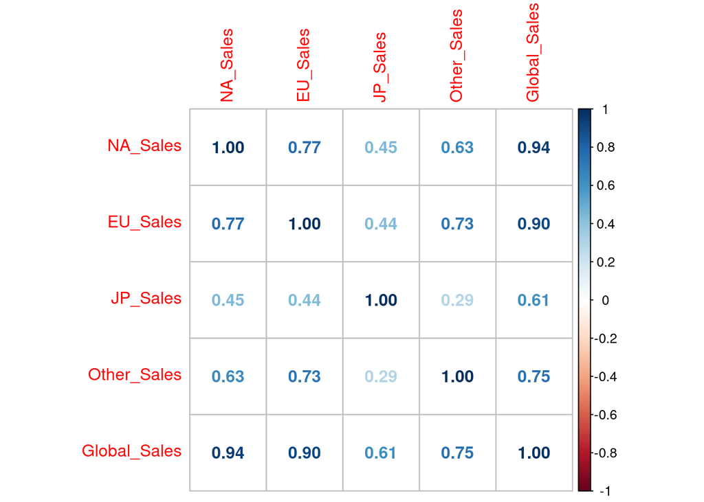

```r
cor(vgsales[,7:11]) %>%corrplot(method = 'number')
```

**Observations**

It appears that there is a strong correlation between NA and EU sales and between EU and other sales. Global sales is a sum so it makes sense that it’s correlation is so high. However, Japanese sales are different from the other sales as its correlation with global sales is low compared to the other variables.

Purpose

We already know what the descriptive states are but now lets look at some histograms

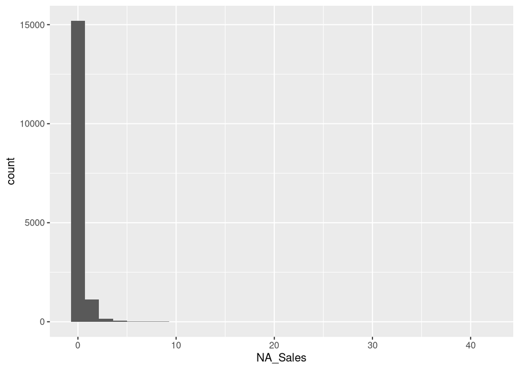

```r
ggplot(vgsales,aes(NA_Sales))+geom_histogram()
```

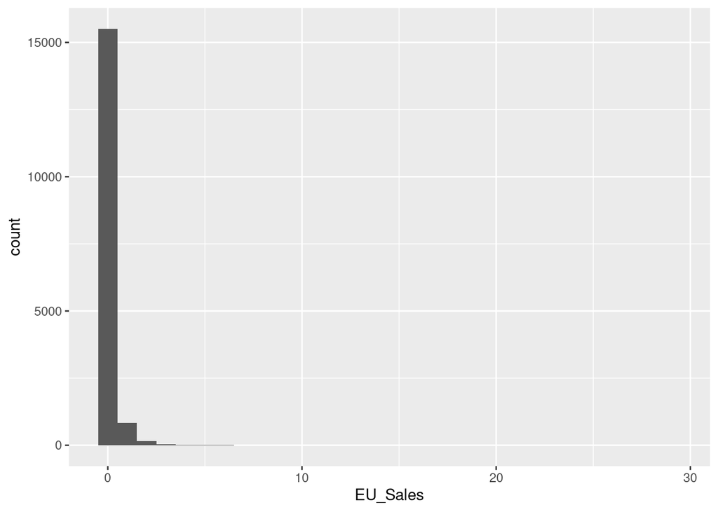

```r
ggplot(vgsales,aes(EU_Sales))+geom_histogram()
```

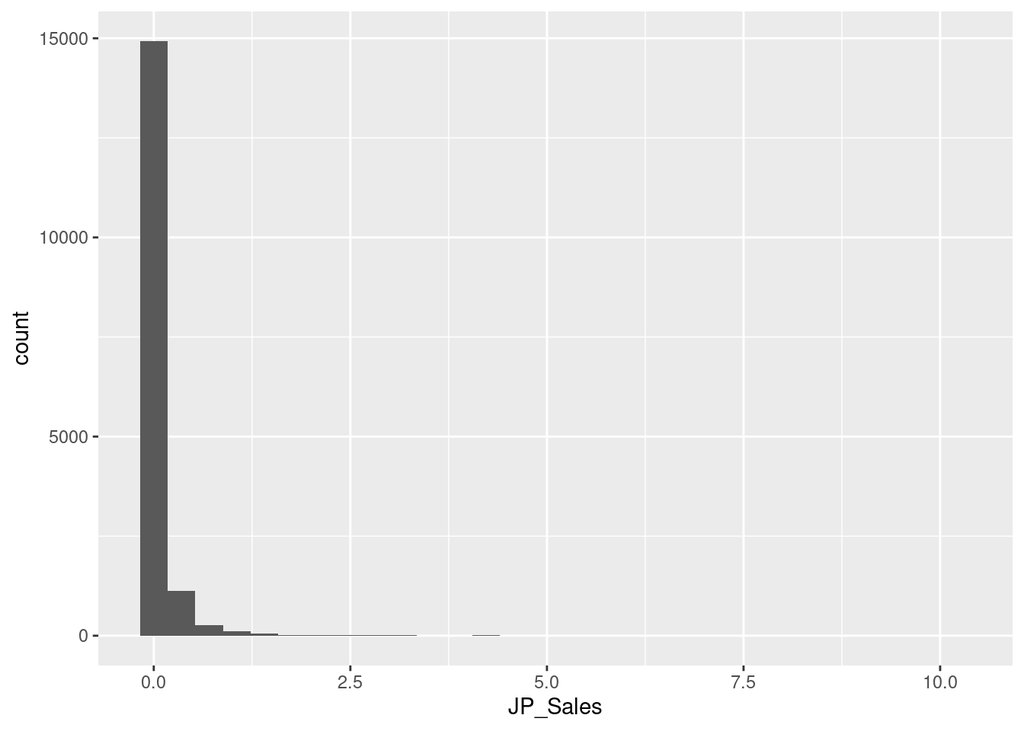

```r
ggplot(vgsales,aes(JP_Sales))+geom_histogram()
```

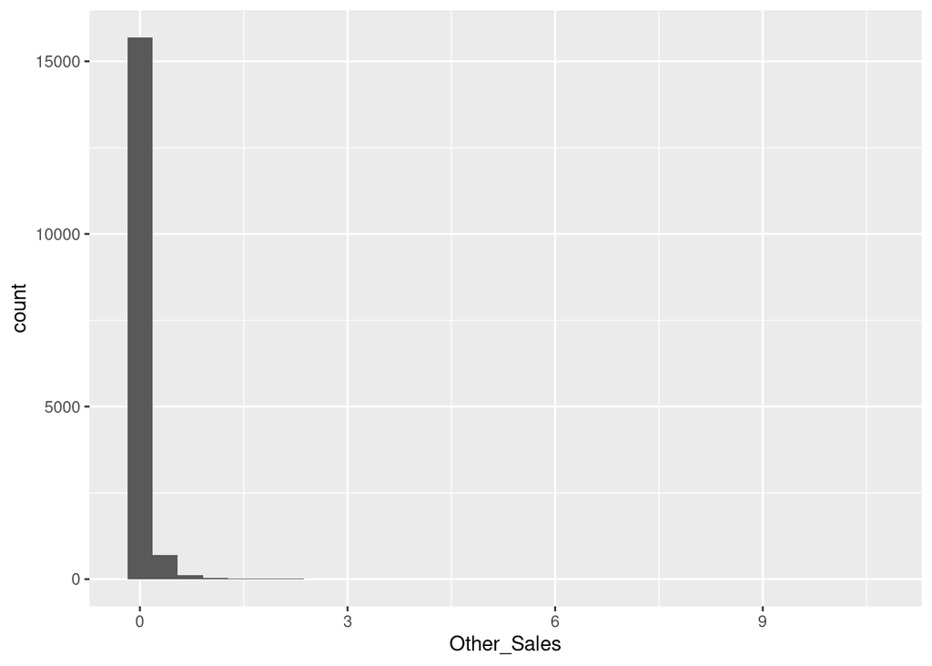

```r
ggplot(vgsales,aes(Other_Sales))+geom_histogram()
```

**Observation**

none of the continuous variables follow a normal distribution. This means we will need to do a log transformation when developing the model